# Billboard Top 100 Data Exploration

# Matthew Ruyter

## Introduction:

It probably comes as no suprise to most that music has undergone a lot of change over the years. Genres of music come and go, and different cultural shifts express themselves in the form of new music year after year. The goal of this project is to identify and analyze the trends of change over the past 50 years, if they exist. The analysis will focus on 50 years of Billboard top 100 tracks, from 1971 to 2020. To develop an idea of the types of song characteristics that we may be looking for, let's observe an example. Take a Billboard top 100 song from 1971 and 2020 which share the same genre, "soft rock". The songs are 'Joy to the World' by Three Dog Night and 'Circles' by Post Malone.

An excerpt of the main verse from Joy to the World looks like:

> Singin' joy to the world  
> All the boys and girls now  
> Joy to the fishes in the deep blue sea  
> Joy to you and me

An excerpt from the main verse of Circles looks like:

> I dare you to do something  
> I'm waiting on you again  
> So I don't take the blame  
> Run away, but we're running in circles  
> Run away, run away, run away

These songs are both within the top 2 songs in their respective years on the Billboard Top 100 charts. An interesting and somewhat obvious observation that can be made is that they take on very different moods. It would appear that Circles from 2020 is defintely more sad than the aformentioned, just by looking at the main verse. This project will look much more closely at this trend, to discern if there is a significant decline or increase in musical characteristics from 1971 to 2020.

### Hypothesis:

$H_{0}:$ music has no discernable pattern of change over the past 50 years of Billboard Top 100s.

$H_{1}:$ music does have discernable patterns of change over the past 50 years of Billboard Top 100s.

```python
import pandas as pd
import matplotlib.pyplot as plt
import numpy as np
#import spotipy
#import lyricsgenius
import seaborn as sns
import re
#import random
#import contractions as con
#import spacy
#from spotipy.oauth2 import SpotifyClientCredentials
from scipy import stats
#!python3 -m spacy download en_core_web_sm
```

## Data Collection:

In order to infer music characteristics for Billboard Top 100 songs, we need a way of retreiving the Billboard Top 100 songs over the 50 year period. To do this, we will use the Spotify API along with a precompiled list of of 50 playlists made by various Spotify users.

First, we establish the connection with the API, using our account's client_id and client_secret keys. These keys will be stored in the file named "Spotify_credentials.txt" in order to not reveal the connection keys openly to the public. The connection will be made by using the python API wrapper named **Spotipy**. It will allow for a relatively seamless connection process and give us access to some very useful functions. An OAuth protocol is used to establish the connection with our credentials.

### Connecting to the Spotify API:

```python
import spotipy
from spotipy.oauth2 import SpotifyClientCredentials

with open('Spotify_credentials.txt') as f:
    keys = f.readlines()
    f.close()

print(keys[0])
# client id:
client_id = keys[0].strip()

print(keys[1])
# client secret:
client_secret = keys[1].strip()

# initialize spotipy, the Spotify API wrapper:
client_credentials_manager = SpotifyClientCredentials(client_id=client_id, client_secret=client_secret)
sp = spotipy.Spotify(client_credentials_manager=client_credentials_manager)
```

```
aa3f1119fe2b4dca8a68a29b99c08b7d

43400b9291384e5d8de6eb4d346bf466
```

### Advantages of the Spotify API:

The Spotify API allows for a lot of cool and useful features to be leveraged. The two that will be particulalry useful is the ability to look up playlists and songs by their unique 22 character alphanumeric ID's, and the ability to look up song audio details by using the audio_features function. The audio_features function returns the following information:

> - **Instrumentalness:** This value represents the amount of vocals in the song. The closer it is to 1.0, the more instrumental the song is.
> - **Acousticness:** This value describes how acoustic a song is. A score of 1.0 means the song is most likely to be an acoustic one.
> - **Liveness:** This value describes the probability that the song was recorded with a live audience. According to the official documentation “a value above 0.8 provides strong likelihood that the track is live”.
> - **Speechiness:** “Speechiness detects the presence of spoken words in a track”. If the speechiness of a song is above 0.66, it is probably made of spoken words, a score between 0.33 and 0.66 is a song that may contain both music and words, and a score below 0.33 means the song does not have any speech.
> - **Energy:** “(energy) represents a perceptual measure of intensity and activity. Typically, energetic tracks feel fast, loud, and noisy”.
> - **Danceability:** “Danceability describes how suitable a track is for dancing based on a combination of musical elements including tempo, rhythm stability, beat strength, and overall regularity. A value of 0.0 is least danceable and 1.0 is most danceable”.
> - **Valence:** “A measure from 0.0 to 1.0 describing the musical positiveness conveyed by a track. Tracks with high valence sound more positive (e.g. happy, cheerful, euphoric), while tracks with low valence sound more negative (e.g. sad, depressed, angry)”.
> - **Key:** A number describing the main group of notes that make up the track.
> - **Loudness:** A value ranging between -60 and 0 dB, describing the loudness of a given track.
> - **Tempo:** The overall estimated tempo of a track in beats per minute (BPM).

While all of these features for each individual song will be compiled into a large dataframe, not all of them will be particulary useful, as we will see.

### Getting the Billboard Top 100 song data:

> The data will be gathered using user created playlists for each of the Billboard Top 100s since 1970. The playlist IDs are unique 22 digit strings of letters an numbers that the Spotify API uses to uniquely identify a playlist. We will iterate through the IDs in the "Top_100_IDs.txt" file and gather the associated information about the songs within.

#### Make an array of all needed playlist IDs, these are in sorted order from 1970 to 2020:

```python
ids = []
with open('Top_100_IDs.txt') as f:
    ids = f.readlines()
    f.close()

for i in range(len(ids)):
    ids[i] = ids[i].strip()
```

Now that we have all of the IDs for each playlist, we can get the respective song information. The information that we are interested in is each individual track ID, name and artist. We get this information by simply iterating over the year interval and using the playlist_tracks function from the API. The track responses are indexable as seen below. These will all be compiled into a dataframe.

```python
i = 0
frames = []
for y in range(1970, 2021):
    tracks = sp.playlist_tracks(ids[i])

    to_frame = []

    for track in tracks['items']:

        #ID
        track_id = (track["track"]["uri"]).split(':')[2]

        #Track name
        track_name = track["track"]["name"]

        #Main Artist
        artist_name = track["track"]["artists"][0]["name"]

        # make the list to be turned into a dataframe
        track_info = [y, track_name, track_id, artist_name]
        to_frame.append(track_info)

    arry = np.array(to_frame)
    df = pd.DataFrame(arry, columns=['year','track','track_ID','artist_name'])
    frames.append(df)
    i+=1
```

#### Let's have look at the complete dataframe:

> - It contains all of the aformentioned data, in order, from 1970 to 2020.

```python
all_song_data = pd.concat(frames)
all_song_data = all_data.reset_index()
all_song_data.sample(5)
```

|  | index | year | track | track_ID | artist_name |
| --- | --- | --- | --- | --- | --- |
| 4713 | 42 | 2017 | Side To Side | 1pKeFVVUOPjFsOABub0OaV | Ariana Grande |
| 2910 | 31 | 1999 | Wild Wild West (feat. Dru Hill & Kool Mo Dee) ... | 5AMvBCtX2rspUdoeJ9IsPN | Will Smith |
| 142 | 42 | 1971 | Never Can Say Goodbye | 5FaJu0i4gRHEXRPA2gfTE8 | The Jackson 5 |
| 1139 | 45 | 1981 | Hit Me With Your Best Shot - 1999 Digital Rema... | 7nrtHjt4Vk4Z5jMHOwaS8F | Pat Benatar |
| 4421 | 50 | 2014 | A Sky Full of Stars | 0FDzzruyVECATHXKHFs9eJ | Coldplay |

One issue that we face with this method of compiling all of the song information is that a few playlists have songs that are no longer available on Spotify. Unfortunately for us, this as unavoidable issue since we wish to investigate our music sample with the audio_features function. We will have to work with what Spotify gives us.

#### Let's see how many songs we have for each year:

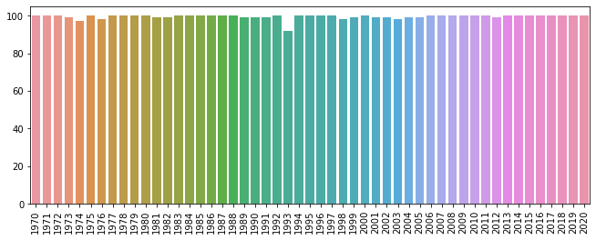

```python
s = all_data['year'].value_counts()
s.sort_index(inplace=True)
plt.figure(figsize = (11,4))
ax = sns.barplot(x = s.index, y = s.values)
adj = plt.xticks(rotation = 90)
```

As can be seen above the majority of years have 100 songs. The year with the most missing data is 1993. This year contains 93 songs rather than 100. Due to the nature of our analysis this will not cause any issues. However, we will keep this fact in mind as we proceed.

### Getting the Billboard Top 100 Audio Data:

> In order to gather the needed audio data we will again be using Spotipy, with the aformentioned audio_features() function. This will return the information described above in the project introduction. We will save this data by iterating through the frames list created above, and adding the appropriate data.

```python
j = 0
for df in frames:
    danceability = []
    energy = []
    key = []
    loudness = []
    speechiness = []
    acousticness = []
    instrumentalness = []
    liveness = []
    valence = []
    tempo = []
    for i,row in df.iterrows():
        audio_data = sp.audio_features([row['track_ID']])
        danceability.append(audio_data[0]['danceability'])
        energy.append(audio_data[0]['energy'])
        key.append(audio_data[0]['key'])
        loudness.append(audio_data[0]['loudness'])
        speechiness.append(audio_data[0]['speechiness'])
        acousticness.append(audio_data[0]['acousticness'])
        instrumentalness.append(audio_data[0]['instrumentalness'])
        liveness.append(audio_data[0]['liveness'])
        valence.append(audio_data[0]['valence'])
        tempo.append(audio_data[0]['tempo'])
    df['danceability'] = danceability
    df['energy'] = energy
    df['key'] = key
    df['loudness'] = loudness
    df['speechiness'] = speechiness
    df['acousticness'] = acousticness
    df['instrumentalness'] = instrumentalness
    df['liveness'] = liveness
    df['valence'] = valence
    df['tempo'] = tempo
    j += 1
```

```python
all_audio_data = pd.concat(frames)
all_audio_data = all_data.reset_index()
all_audio_data.sample(5)
```

As to avoid the long processing time for the above data frame, we will export it to a csv file so that it can be imported quickly in the future.

```python
complete = pd.concat(frames)
complete.reset_index()
complete.to_csv('complete_data.csv')
```

On import, we re-split the complete dataframe into a list of individual frames again. This will make some operations much easier, like graphing.

```python
complete_data = pd.read_csv('complete_data.csv')
imported_frames = []
i = 0
for year in range(1971, 2021):
    imported_frames.append(complete_data.loc[complete_data['year'] == year])
    imported_frames[i] = imported_frames[i].drop(imported_frames[i].columns[[0]], axis = 1)
    imported_frames[i] = imported_frames[i].reset_index()
    i += 1
```

```python
imported_frames[0].sample(5)
```

|  | index | year | track | track_ID | artist_name | danceability | energy | key | loudness | speechiness | acousticness | instrumentalness | liveness | valence | tempo |
| --- | --- | --- | --- | --- | --- | --- | --- | --- | --- | --- | --- | --- | --- | --- | --- |
| 5 | 105 | 1971 | One Bad Apple | 3PPPJz714ibZsmjLnoJklx | The Osmonds | 0.594 | 0.561 | 0 | -8.878 | 0.0507 | 0.420 | 0.000000 | 0.4670 | 0.886 | 100.601 |
| 21 | 121 | 1971 | The Night They Drove Old Dixie Down | 3Vms3ZKJF7CXWppSejBPxL | Joan Baez | 0.575 | 0.355 | 1 | -12.668 | 0.0332 | 0.595 | 0.000000 | 0.1040 | 0.453 | 129.317 |
| 53 | 153 | 1971 | Yo-Yo | 2AX44XQ1U457W0VaYyTf3p | The Osmonds | 0.633 | 0.713 | 2 | -8.812 | 0.0674 | 0.578 | 0.000000 | 0.3530 | 0.916 | 139.460 |
| 68 | 168 | 1971 | She’s Not Just Another Woman | 7BqjztX1nCwJxt5mwHryZ3 | The 8th Day | 0.737 | 0.680 | 5 | -9.124 | 0.1750 | 0.258 | 0.000000 | 0.0339 | 0.882 | 80.169 |
| 19 | 119 | 1971 | Mr. Big Stuff | 08013W2oJiJ3FcVq24hjXO | Jean Knight | 0.889 | 0.655 | 8 | -6.684 | 0.1230 | 0.301 | 0.000005 | 0.0970 | 0.968 | 93.252 |

### Let's look at our data:

Now that the data has been gathered, let's take a look at it. We are specicifically looking for trends over the 50 year period. First we will create a dataframe of averages for each audio characteristic and year, respectively.

```python
# create dataframe containing averages for each year
avgs = []
for df in imported_frames:
    year_stats = [df.loc[0,'year'], df['danceability'].mean(), df['energy'].mean(), df['key'].mean(), df['loudness'].mean(),
                  df['speechiness'].mean(), df['acousticness'].mean(), df['instrumentalness'].mean(),
                  df['liveness'].mean(), df['valence'].mean(), df['tempo'].mean()]
    avgs.append(year_stats)

arry = np.array(avgs)
averages = pd.DataFrame(arry, columns = ['year', 'avg_danceability', 'avg_energy', 'avg_key', 'avg_loudness',
                                         'avg_speechiness', 'avg_acousticness', 'avg_instrumentalness',
                                         'avg_liveness', 'avg_valence', 'avg_tempo'])
```

### Plot each of the characteristics:

In order to see the data, we will make regression plots for each of the audio characteristics. The points on the plots will come from the averages dataframe.

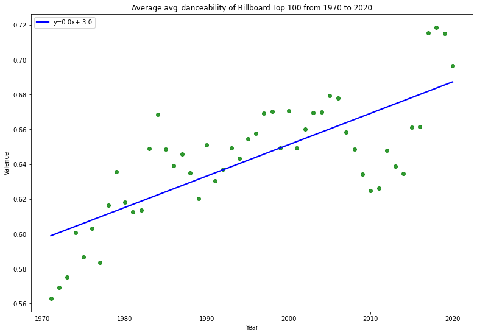

```
0.5989250794143035
0.6872466401403576
```

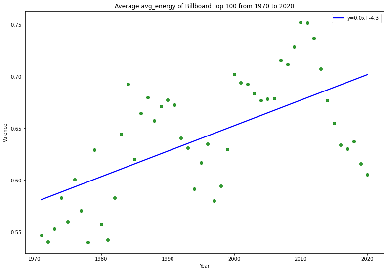

```
0.5811991397351006
0.701789761133333
```

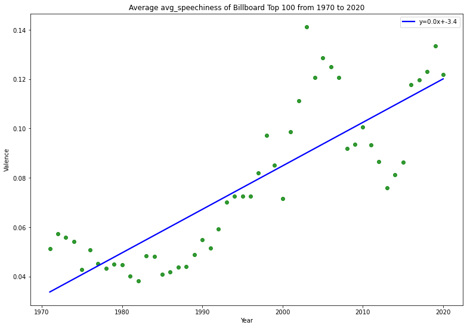

```
0.03376934145592436
0.12009646455751666
```

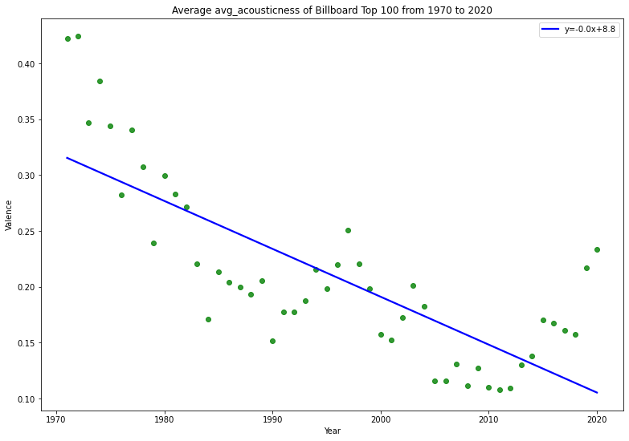

```
0.3154277880845786
0.10525127134717316
```

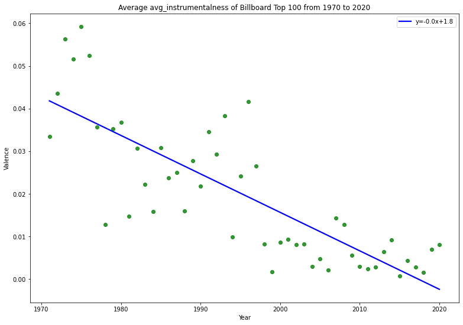

```
0.04180334995985091
-0.00241903346682526
```

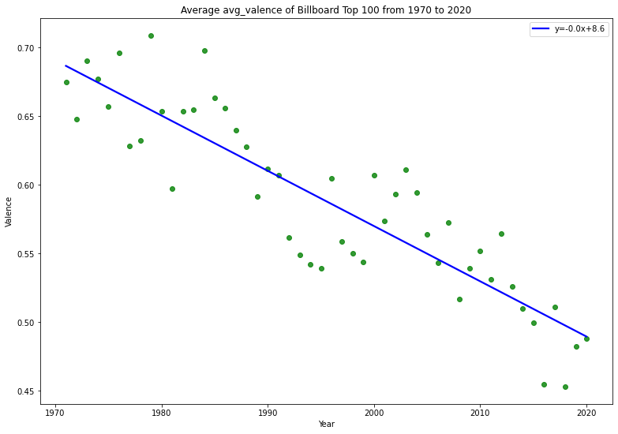

```
0.6865694215867721
0.48940130866745335
```

```python
for cn,cd in averages.iteritems():
    if (cn != 'year') & (cn != 'avg_key') & (cn != 'avg_loudness') & (cn != 'avg_liveness') & (cn != 'avg_tempo'):
        plt.figure(figsize = (13, 9))

        # get coeffs of linear fit
        slope, intercept, r_value, p_value, std_err = stats.linregress(averages['year'],averages[cn])

        # use line_kws to set line label for legend
        ax = sns.regplot(x='year', y=cn, data=averages, color='b', ci = None,
                         scatter_kws={'color': 'green'},
                         line_kws={'label':"y={0:.1f}x+{1:.1f}".format(slope,intercept)})

        #name the plot
        plt.title('Average '+cn+' of Billboard Top 100 from 1970 to 2020')
        plt.xlabel('Year')
        plt.ylabel('Valence')

        # plot legend
        ax.legend()

        # show plot
        plt.show()

        start = (slope*1971)+intercept
        end = (slope*2020)+intercept
        print(start)
        print(end)
```

Some initial key observations from the above graphs follow:

> - There is a steady decline in valence throughout the last 50 years. This means that the overall positivity conveyed by top tracks has decreased over the timeframe.
> - The average energy of songs also appears to be on the rise, with a sharp decrease occuring around 2010, up to the year 2020.

This is in support of the alternative hypothesis, which states that there has been a change in the type of music that is most popular over the 50 years.

In order to identify a clear change in popular music over the past 50 years, let's define a new metric. The metric will be attitude, and it will depend on energy and valence. The attitude classes will be as follows:

> - **Agressive:** classifies songs with lower than average valence and higher than average enregy.
> - **Happy:** classifies songs with higher that average valence and higher than average energy.
> - **Sad:** classifies songs with lower then average valence and lower than average energy.
> - **Calm:** classifies songs with higher than average valence and lower than average valence.

### Generating a new metric: Attitude

In order to analyze the attitude of the Billboard tracks over the past 50 years, we will take random samples of the data. The data will be sampled by taking a random subset of 25 tracks from each year. In total, we will plot the attitude of 1,250 tracks. The data will be categorized into two 25 year intervals. Ideally, we will be able to see clusters of songs from the 2 intervals in different quadrants of the scatter plot. This will allow us to conclude that the attitude of music has changed over time.

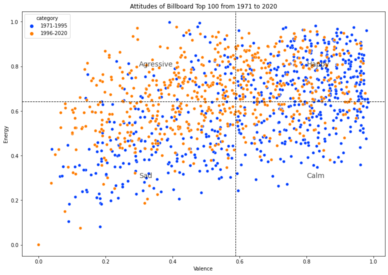

```python
# we will need the random import in order to sample
import random

# range is different depending on the year.
sampled_data = []
for df in imported_frames:
    # generating the indicies of the ranfom sample
    sample_indicies = random.sample(range(0,df.shape[0]), 25)
    sample_df = df.iloc[sample_indicies,[1,6,13]]
    sampled_data.append(sample_df)

for df in sampled_data:
    df['category'] = 0
    for i,row in df.iterrows():
        if row['year'] in range(1971,1996):
            df['category'] = '1971-1995'
        if row['year'] in range(1996,2021):
            df['category'] = '1996-2020'

all_samples = pd.concat(sampled_data)

# now the data is sampled we can attempt to make the scatter plot
plt.figure(figsize = (13, 9))
sns.scatterplot(data = all_samples, x = 'valence', y = 'energy', hue = 'category', palette= 'bright')
plt.title('Attitudes of Billboard Top 100 from 1971 to 2020')
plt.xlabel('Valence')
plt.ylabel('Energy')

#Quadrant Marker
plt.text(x=0.8, y=0.30, s="Calm",alpha=0.7,fontsize=14, color='black')
plt.text(x=0.3, y=0.30, s="Sad",alpha=0.7,fontsize=14, color='black')
plt.text(x=0.3, y=0.80, s="Agressive", alpha=0.7,fontsize=14, color='black')
plt.text(x=0.8, y=0.80, s="Happy", alpha=0.7,fontsize=14, color='black')

# Benchmark Mean values
plt.axhline(y= averages['avg_energy'].mean(), color='k', linestyle='--', linewidth=1)
plt.axvline(x= averages['avg_valence'].mean(), color='k',linestyle='--', linewidth=1)

#display
plt.show()
```

The plot seems somewhat obfuscated at first glance, however there are discernable conclusions that can be made. There is a higher concentration of songs from the 1971-1995 era in the "calm" quadrant of the plot, and a higher concentration of songs from the 1996-2020 era in the aggressive portion of the plot.

#### Two tailed Z-test:

We will use the **stats** and **stests** mudules in order to conduct a two tailed z test on the above data. Our test will conclude whether our samples of music from 1971-1995 and 1996-2020 differ significantly with respect to average valence, when compared to the mean valence of the entire 50 years.

The average valence of of the entire dataset is given as:

```python
print(complete_data['valence'].mean())
```

```
0.5895640702031159
```

```python
from scipy import stats
from statsmodels.stats import weightstats as stests

interval1 = all_samples.loc[all_samples['category'] == '1971-1995']
interval2 = all_samples.loc[all_samples['category'] == '1996-2020']

# first test, on interval 1
ztest1 ,pval1 = stests.ztest(interval1['valence'], x2=None, value=0.58956)

# second test, on interval 2
ztest2 ,pval2 = stests.ztest(interval2['valence'], x2=None, value=0.58956)

# make the display nice
d = {'interval': ['1971-1995','1996-2020'],
     'pval': [pval1, pval2],
     'reject Ho at alpha 0.25':['yes','yes'],
     'mean': [interval1['valence'].mean(), interval2['valence'].mean()]}
test = pd.DataFrame(data = d)

display(test)
```

|  | interval | pval | reject Ho at alpha 0.25 | mean |
| --- | --- | --- | --- | --- |
| 0 | 1971-1995 | 1.839061e-06 | yes | 0.637132 |
| 1 | 1996-2020 | 6.297750e-10 | yes | 0.532670 |

In each test, we can very well conclude that the mean valence of our samples differs significantly from the mean of the entire dataset. We **reject** the **null** hypothesis. Additionally, we can clearly see the observed results from the graph. The mean valence of the earlier interval was higher by approximately .10. This describes explicitly the shift of music from 'calm' and 'happy' to 'sad' and 'agressive' over the last 50 years of Billboard Top 100s.

### Analyzing uniqueness:

In the plots above, we see that 'speechiness', Spotify's metric for number of spoken words in a song, is increasing on average. What is interesting about this data is that while acousticness and instrumentalness are decreasing, danceability and speechiness appear to be increasing. This could be due to the nature of the instruments used to create popular music in more recent times. As more technology is used to create melodies, the instrumental and acoustic values of songs go down. However danceability, based on tempo, rhythm stability, beat strength, and overall regularity of the song, goes up. With all of these factors at play, we still observe an increased number of spoken words in song on average, as indicated by the speechiness values of the tracks.

#### Observation:

to get a better understanding of the speechiness of the selected tracks, we will compare uniqueness of words over 10 year intervals. Since speachiness is increasing over the 50 years, the expected result is that newer music will have a higher uniqueness value than older music.

### Connecting to the Genius Lyrics API:

We will be using the Genius Lyrics API in order to collect the lyric data for the Billboard Top 100 songs. Similarly to the above Spotify API connection, we will streamline the process by utilizing a nice wrapper for teh Genius API, called **lyricsgenius**.

Here we extablish a connection to the API, using the user credentials stored in the local directory titled "genius_tokens.txt".

```python
# import the lyricsgenius API
import lyricsgenius

# create a connection to the Genius API
with open('genius_token.txt') as f:
    token = f.readlines()[0]
f.close()
gen = lyricsgenius.Genius(token)
```

Now we can utilize the API's functionality to retrieve the lyrics of every single song in our 50 year interval. The lyrics are found by iterating all of the songs. For each song, we search the song using it's name and the search_song function. If we get a result from the search, we then get the lyrics by the song.lyrics operation. The lyrics that are scraped contain breaks, brackets, and various song element descriptors that we would like to parse out. This will be during the iteration of all of the songs.

Note: Due to the excessive time (2 hours) it takes to retrieve all of the lyrics, this was only executed a single time and then the data was exported to a csv stored in the local directory for ease of data usage in the future.

```python
## EXECUTED ONCE, DATA DOWNLOADED TO A .CSV##
#for frame in imported_frames:
for frame in imported_frames:
    frame['lyrics'] = np.nan
    print(frame.loc[0, 'year'])
    for i,row in frame.iterrows():
        while True:
            try:
                song = gen.search_song(frame.loc[i,'track'], frame.loc[i,'artist_name'])
                j += 1
                break
            except:
                pass
        if song != None:
            lyrics = (re.sub(r'[\(\[].*?[\)\]]', '', song.lyrics)).splitlines()
            lyrics.pop(0)
            lyrics = ' '.join(lyrics)
            frame.loc[i,'lyrics'] = lyrics

billboard_lyrics = pd.concat(imported_frames)
billboard_lyrics.reset_index()
billboard_lyrics.to_csv('billboard_lyrics.csv')
```

Code to read in the lyric data from the csv file subsequent times:

```python
lyric_data = pd.read_csv('billboard_lyrics.csv')
lyrics = []
i = 0
for year in range(1970, 2021):
    lyrics.append(lyric_data.loc[lyric_data['year'] == year])
    lyrics[i] = lyrics[i].drop(lyrics[i].columns[0], axis = 1)
    lyrics[i] = lyrics[i].reset_index()
    i += 1
```

Some lyrics were not able to be found in the process of scraping them from Genius. Let's see how many songs we could not gather data for by checking for the default nan values in the data frame.

```python
print(lyric_data['lyrics'].isnull().sum())
```

```
239
```

There are 239 entries in the complete table that we were not able to find lyrics for. For now on with the lyric analysis, we will be working with a subset of 4832 songs. This will still be an adequite number of songs to do our analysis with. We will will remove these nan entries for the remainder of the analysis. However, we will keep the missing data in mind as we proceed.

```python
# remove nan
lyric_data['lyrics'] = lyric_data['lyrics'].replace(np.nan, 0)
for i,row in lyric_data.iterrows():
    if row['lyrics'] == 0:
        data = lyric_data.drop(labels = i, axis = 0, inplace = True)
    else:
        lyric_data.loc[i,'lyrics'] = (lyric_data.loc[i,'lyrics']).lower()
lyric_data.sample(5)
```

|  | Unnamed: 0 | index | year | track | track_ID | artist_name | danceability | energy | key | loudness | speechiness | acousticness | instrumentalness | liveness | valence | tempo | lyrics |
| --- | --- | --- | --- | --- | --- | --- | --- | --- | --- | --- | --- | --- | --- | --- | --- | --- | --- |
| 3501 | 28 | 3501 | 2005 | Let Me Hold You (feat. Omarion) | 1oNToERLIN71YCPLbRIQGQ | Bow Wow | 0.815 | 0.662 | 6 | -8.244 | 0.199 | 0.0915 | 0.000409 | 0.0898 | 0.611 | 151.518 | y'all know what this is this what you need to ... |
| 1274 | 81 | 1274 | 1982 | Get Down On It | 4cdOa74e9tBGA6FaVT5mgc | Kool & The Gang | 0.880 | 0.633 | 7 | -6.331 | 0.061 | 0.2190 | 0.000039 | 0.0609 | 0.970 | 110.864 | what you gonna do? you wanna get down? tell me... |
| 4825 | 54 | 4825 | 2018 | Freaky Friday (feat. Chris Brown) | 10Igtw8bSDyyFs7KIsKngZ | Lil Dicky | 0.755 | 0.599 | 8 | -5.042 | 0.224 | 0.1470 | 0.000000 | 0.1090 | 0.755 | 133.123 | kygo & miguel - remind me to forget halsey - a... |
| 4623 | 52 | 4623 | 2016 | Exchange | 43PuMrRfbyyuz4QpZ3oAwN | Bryson Tiller | 0.525 | 0.433 | 6 | -10.598 | 0.185 | 0.1070 | 0.000000 | 0.1350 | 0.276 | 160.108 | this what happen when i think 'bout you i get ... |
| 847 | 53 | 847 | 1978 | Disco Inferno - Single Edit | 22ff60cZy4APp7bzESHLR8 | The Trammps | 0.763 | 0.819 | 10 | -4.780 | 0.036 | 0.0641 | 0.123000 | 0.2350 | 0.911 | 129.288 | sylvester - you make me feel sister sledge - ... |

#### Cleaning the lyrics further:

We will separate contractions as to not confuse single letters with words when anlayzing lyrics. Also, we will remove certain words that have no contextual meaning but will surely occur often, such as 'and', 'of', 'or',...etc. In order to parse out these words, we will use the spaCy and contractions libraries.

> **SpaCy** will allow us to introduce a precompiled dictionary of 'stopwords'. Stopwords are the words described above, and comparing the lyrics here to the dictionary will allow us to get rid of them.

> the **contractions** library will allow us to remove contrains by way of the fix() function on each indidual lyric. This library contains precompiled contractions which it matches these lyrics to. Once it matches, it replaces that contraction with the expanded form. ie: 'would've' becomes 'would have'.

```python
# import contractions and spaCy
import contractions
import spacy

# Used remove words that hold no semantic meaning: 'stopwords'
stopwords = (spacy.load('en_core_web_sm')).Defaults.stop_words

#copy lyric data for next part:
less_clean_lyrics = lyric_data

for i,row in lyric_data.iterrows():
    expanded = []
    lyrics1 = row['lyrics']

    # remove contractions:
    for lyric in lyrics1.split():
        expanded.append(contractions.fix(lyric))
    lyrics2 = ' '.join(expanded)

    # remove stop words:
    no_stops = [lyric for lyric in lyrics2.split() if lyric not in stopwords]
    lyrics3 = ' '.join(no_stops)

    # replace in the dataframe:
    lyric_data.loc[i,'lyrics'] = lyrics3
```

Now that the lyrics are clean, we can use them in our analysis of lyric uniqueness. This uniqueness value for each year interval will be calculated as $ratio_{unique}$. A value closer to 1 indicates a large number of unique lyrics.

$ratio_{unique} = \frac{lyric_{unique}}{lyric_{total}}$. here, $lyric_{unique}$ is the number of unique lyrics, and $lyric_{total}$ is the total number of lyrics.

The count_unique function simply accumulates lyrics and as it iterates further, it checks against the accumulator, and adds if the current lyric is not already in the accumulator.

```python
def count_unique(sub_str):
    acc = []
    for i in range(0,len(sub_str)):
        if sub_str[i] not in acc:
            acc.append(sub_str[i])
    return len(acc)

ratios = []
for i in range(1971,2021):
    sub_str = ' '
    sub_df = lyric_data.loc[lyric_data['year'] == i]
    for j,row in sub_df.iterrows():
        sub_str += row['lyrics']

    # get the length of the lyric text for year i:
    num_lyrics = len(sub_str.split())

    # count the unique lyrics for year i:
    num_unique = count_unique(sub_str.split())

    # calculate the ratio
    ratio = num_unique/num_lyrics

    # make the list
    ratios.append([i,ratio])

ratio_df1 = pd.DataFrame(ratios, columns = ['year','ratio'])
```

#### Look at the uniqueness ratios:

Let's put together a bar plot to look at the uniqueness ratios over the years.

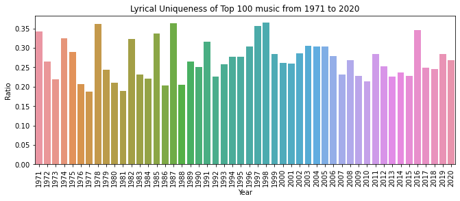

```python
# make a bar plot
plt.figure(figsize = (11,4))
ax = sns.barplot(x = ratio_df1['year'], y = ratio_df1['ratio'])
adj = plt.xticks(rotation = 90)
plt.title('Lyrical Uniqueness of Top 100 music from 1971 to 2020')
plt.xlabel('Year')
plt.ylabel('Ratio')
plt.show()
```

Interestingly, the plot above does not show a very clear linear increase in lyric uniqueness that we expected. This result was expected due to the speechiness values of songs increasing over time. The fact that we did not observe the expected result indicates that even though newer music is more wordy, it actually doesn't contain a significantly larger proportion of unique lyrics. In fact, the highest spikes in this ratio are in the 80's and the late 90s.

#### Observation:

Is one interval, such as 1971-1995, more word-wise unique than the 1996-2020 interval? Word uniqueness seems to not have linearly increased or decreased over time, which is interesting because speachiness has increased over time. One would think that the period with more speaking would contain more unique words, or at least have a higher probability of containing more unique words.

#### Let's find out which period really is more unique:

We'll compare the 1971-1995 period to 1996-2020. The mean ratio over all time is given by:

```python
print(ratio_df1['ratio'].mean())
```

```
0.2693644228512843
```

```python
# ready the frame
ratio_df1['category'] = 0
for i,row in ratio_df1.iterrows():
    if row['year'] in range(1971,1996):
        ratio_df1.loc[i, 'category'] = '1971-1995'
    elif row['year'] in range(1996,2021):
        ratio_df1.loc[i, 'category'] = '1996-2020'

interval1 = ratio_df1.loc[ratio_df1['category'] == '1971-1995']
interval2 = ratio_df1.loc[ratio_df1['category'] == '1996-2020']

# first test, on interval 1
ztest1 ,pval1 = stests.ztest(interval1['ratio'], x2=None, value=0.26936)

# second test, on interval 2
ztest2 ,pval2 = stests.ztest(interval2['ratio'], x2=None, value=0.26936)

# make the display nice
d = {'interval': ['1971-1995','1996-2020'],
     'pval': [pval1,pval2],
     'reject Ho at 0.25': ['no', 'no'],
     'mean ratio': [interval1['ratio'].mean(), interval2['ratio'].mean()]}
test = pd.DataFrame(data = d)
display(test)
```

|  | interval | pval | reject Ho at 0.25 | mean ratio |
| --- | --- | --- | --- | --- |
| 0 | 1971-1995 | 0.618106 | no | 0.263823 |
| 1 | 1996-2020 | 0.496597 | no | 0.274905 |

We cannot reject the null hypothesis by a great amount, so we cannot conclude that the uniqueness of words is significantly different between the 2 time periods.

## Conclusion:

We were able to gather some interesting points of data from our analysis. The key point being that yes, in fact, Billboard Top 100 music has experienced quite a few changes over the past 50 years. We reject the null hypothesis that things have remained largely the same. The nature of this change seem to be that music is shifting into a more negative direction and that there are more words used in popular music today, but the overall respective vocabulary ranges have remained largely the same.

## References:

SpaCy: https://towardsdatascience.com/text-pre-processing-stop-words-removal-using-different-libraries-f20bac19929a

Contraction library: https://www.geeksforgeeks.org/nlp-expand-contractions-in-text-processing/

Spotify API: https://developer.spotify.com/documentation/web-api/

Spotipy: https://spotipy.readthedocs.io/en/2.19.0/

Lyricsgenius: https://lyricsgenius.readthedocs.io/en/master/

Testing: https://towardsdatascience.com/hypothesis-testing-in-machine-learning-using-python-a0dc89e169ce